# Fungal compositional analysis on frog skins across localities and vertical positions

### C2. Top ASVs de `p__Basidiomycota`

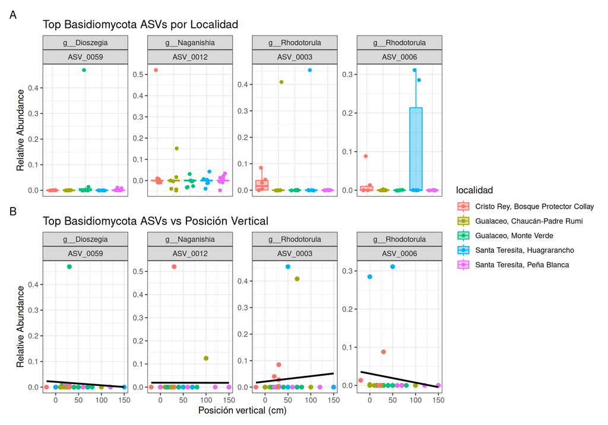

```r
# Seleccionar los 4 ASVs más abundantes de Basidiomycota
top_basidio_ASVs <-
  ASV_df %>%
  dplyr::filter(Phylum == "p__Basidiomycota") %>%
  group_by(ASV) %>%
  summarize(mean_Abundance = mean(Abundance), .groups = "drop") %>%
  arrange(-mean_Abundance) %>%
  head(n = 4) %>%
  pull(ASV)

# Plot ASVs por Localidad
basidio_asv_loc <-
  ASV_df %>%
  dplyr::filter(ASV %in% top_basidio_ASVs) %>%
  ggplot(aes(x = localidad, y = Abundance,
             fill = localidad, color = localidad)) +
  facet_wrap(Genus ~ ASV, scales = "free_y", nrow = 1) +
  geom_boxplot(alpha = 0.4, outlier.shape = NA) +
  geom_jitter(width = 0.2, size = 1.5) +
  theme_bw() +
  labs(title = "Top Basidiomycota ASVs por Localidad", x = NULL, y = "Relative Abundance") +
  scale_color_manual(values = localidad_colors) +
  scale_fill_manual(values = localidad_colors) +
  theme(axis.text.x = element_blank(),
        axis.ticks.x = element_blank(),
        legend.position = "right")

# Plot ASVs vs Posición Vertical
basidio_asv_altura <-
  ASV_df %>%
  dplyr::filter(ASV %in% top_basidio_ASVs) %>%
  ggplot(aes(x = posicion_vertical_cm, y = Abundance)) +
  facet_wrap(Genus ~ ASV, scales = "free_y", nrow = 1) +
  geom_point(aes(color = localidad), size = 2) +
  theme_bw() +
  geom_smooth(method = "lm", color = "black", se = FALSE) +
  labs(title = "Top Basidiomycota ASVs vs Posición Vertical", x = "Posición vertical (cm)", y = "Relative Abundance") +
  scale_color_manual(values = localidad_colors) +
  theme(legend.position = "none")

# Combinar
basidio_asv_loc / basidio_asv_altura +
  plot_layout(guides = "collect") +
  plot_annotation(tag_levels = "A")
```

INTERPRETATION #6: Were the most abundant ASVs in your dataset represented in your ASV-level plots? If not, please go back and plot them specifically. (Hint: Remember that we ordered our ASV names by abundance across the entire dataset. Therefore, ASV_0001 will be the most abundant, ASV_0007 will be the 7th most abundant and so on.)

INTERPRETATION #7: Please make some plots at the ASV level as it relates to your scientific question. Were there any ASVs that were especially related to trends that you saw? Did a specific phylogenetic group all show the same trends (e.g. like the Actinomycetota ASVs above)? Or did the ASVs have various, likely niche-specific responses (similar to the Cyanobacteriota above)??

INTERPRETATION #8: Now, do a quick literature or google search and look back in the paper that you may be replicating (if applicable). Does your ASV-level changes represent something that is currently known? Or is this a novel result? What did you learn about this ASV or a group of ASVs in your dataset?

# Final info for Reproducibility

## Check Render Time

```r
# Take the time now that we are at the end of the script
end_time <- Sys.time()
end_time
```

```
## [1] "2026-11-16 13:14:31 UTC"
```

```r
# Echo the elapsed time
elapsed_time <- round((end_time - start_time), 3)
elapsed_time
```

```
## Time difference of 16.433 secs
```